# Analyze_ab_test_results_notebook(2)

## Analyze A/B Test Results

- Introduction
- Part I - Probability
- Part II - A/B Test
- Part III - Regression

### Introduction

A/B tests are very commonly performed by data analysts and data scientists.

#### Part I - Probability

To get started, let's import our libraries.

```python
import pandas as pd
import numpy as np
import random
import matplotlib.pyplot as plt
%matplotlib inline
#Setting the seed
random.seed(42)
```

Now, reading the `ab_data.csv` data. Storing it in `df`.

Reading the dataset and having a look at the top few rows here:

```python
df=pd.read_csv('ab_data.csv')
df.head()
```

|  | user_id | timestamp | group | landing_page | converted |
| --- | --- | --- | --- | --- | --- |
| 0 | 851104 | 2017-01-21 22:11:48.556739 | control | old_page | 0 |
| 1 | 804228 | 2017-01-12 08:01:45.159739 | control | old_page | 0 |
| 2 | 661590 | 2017-01-11 16:55:06.154213 | treatment | new_page | 0 |
| 3 | 853541 | 2017-01-08 18:28:03.143765 | treatment | new_page | 0 |
| 4 | 864975 | 2017-01-21 01:52:26.210827 | control | old_page | 1 |

Number of rows in the dataset.

```python
df.shape[0]
```

```
294478
```

Number of unique users in the dataset.

```python
df.user_id.nunique()
```

```
290584
```

The proportion of users converted.

```python
k=df.groupby(['user_id'])['converted'].mean()
t=pd.DataFrame(k)
t.mean()
```

```
converted    0.119556
dtype: float64
```

The number of times the `new_page` and `treatment` don't match.

```python
df[((df['group'] == 'treatment') != (df['landing_page'] == 'new_page')) == True].shape[0]
```

```
3893
```

Do any of the rows have missing values?

```python
df.info()
```

```
<class 'pandas.core.frame.DataFrame'>
RangeIndex: 294478 entries, 0 to 294477
Data columns (total 5 columns):
user_id         294478 non-null int64
timestamp       294478 non-null object
group           294478 non-null object
landing_page    294478 non-null object
converted       294478 non-null int64
dtypes: int64(2), object(3)
memory usage: 11.2+ MB
```

For the rows where **treatment** does not match with **new_page** or **control** does not match with **old_page**, we cannot be sure if this row truly received the new or old page.

```python
df.drop(df.query("group == 'treatment' and landing_page == 'old_page'").index, inplace=True)
df.drop(df.query("group == 'control' and landing_page == 'new_page'").index, inplace=True)
```

```python
df.to_csv('ab_edited.csv', index=False)
```

```python
df2 = pd.read_csv('ab_edited.csv')
```

```python
# Double Check all of the correct rows were removed - this should be 0
df2[((df2['group'] == 'treatment') == (df2['landing_page'] == 'new_page')) == False].shape[0]
```

```
0
```

**User_id**s in **df2**

```python
df2.user_id.nunique()
```

```
290584
```

**User_id** repeated in **df2**.

```python
df2.user_id.value_counts()
```

```
773192    2
630732    1
811737    1
797392    1
795345    1
801490    1
799443    1
787157    1
793302    1
817882    1
842446    1
815835    1
805596    1
803549    1
809694    1
```

[output cut: 47 more lines]

Row information for the repeat **user_id**

```python
df2.query('user_id == 773192')
```

|  | user_id | timestamp | group | landing_page | converted |
| --- | --- | --- | --- | --- | --- |
| 1876 | 773192 | 2017-01-09 05:37:58.781806 | treatment | new_page | 0 |
| 2862 | 773192 | 2017-01-14 02:55:59.590927 | treatment | new_page | 0 |

Removing **one** of the rows with a duplicate **user_id**, but keeping dataframe as **df2**.

```python
df2.drop_duplicates('user_id',inplace=True)
```

```python
# Checking for above operation
df2.query('user_id == 773192')
```

|  | user_id | timestamp | group | landing_page | converted |
| --- | --- | --- | --- | --- | --- |
| 1876 | 773192 | 2017-01-09 05:37:58.781806 | treatment | new_page | 0 |

What is the probability of an individual converting regardless of the page they receive?

```python
df2['converted'].mean()
```

```
0.11959708724499628
```

Given that an individual was in the `control` group, what is the probability they converted?

```python
df_grp = df2.groupby('group')
df_grp.describe()
```

| group | converted count | converted mean | converted std | converted min | converted 25% | converted 50% | converted 75% | converted max | user_id count | user_id mean | user_id std | user_id min | user_id 25% | user_id 50% | user_id 75% | user_id max |
| --- | --- | --- | --- | --- | --- | --- | --- | --- | --- | --- | --- | --- | --- | --- | --- | --- |
| control | 145274.0 | 0.120386 | 0.325414 | 0.0 | 0.0 | 0.0 | 0.0 | 1.0 | 145274.0 | 788164.072594 | 91287.914601 | 630002.0 | 709279.50 | 788128.5 | 867208.25 | 945998.0 |
| treatment | 145310.0 | 0.118808 | 0.323564 | 0.0 | 0.0 | 0.0 | 0.0 | 1.0 | 145310.0 | 787845.719290 | 91161.564429 | 630000.0 | 708745.75 | 787876.0 | 866718.75 | 945999.0 |

Given that an individual was in the `treatment` group, what is the probability they converted?

```python
#Answer can inferred from above table for treatment group
```

What is the probability that an individual received the new page?

```python
df2.query('landing_page == "new_page"').user_id.nunique()/df2.user_id.nunique()
```

```
0.5000619442226688
```

Conclusion

No, there is insufficient evidence that new treatment leads to more conversions as the results obtained are reverse.

### Part II - A/B Test

The **conversion rate** for $p_{new}$ under the null

```python
p_new=df2['converted'].mean()
p_new
```

```
0.11959708724499628
```

The **conversion rate** for $p_{old}$ under the null

```python
p_old=df2['converted'].mean()
p_old
```

```
0.11959708724499628
```

$n_{new}$, the number of individuals in the treatment group

```python
n_new=df2.query('group =="treatment"').user_id.nunique()
n_new
```

```
145310
```

$n_{old}$, the number of individuals in the control group

```python
n_old=df2.query('group =="control"').user_id.nunique()
n_old
```

```
145274
```

Simulating $n_{new}$ transactions with a conversion rate of $p_{new}$ under the null and storing these $n_{new}$ 1's and 0's in **new_page_converted**.

```python
new_page_converted = np.random.choice([0,1],n_new, p=(1-p_new,p_new))
new_page_converted
```

```
array([0, 0, 0, ..., 0, 0, 0])
```

Simulate $n_{old}$ transactions with a conversion rate of $p_{old}$ under the null storing these $n_{old}$ 1's and 0's in **old_page_converted**.

```python
old_page_converted = np.random.choice([0,1],n_old, p=(1-p_old,p_old))
old_page_converted
```

```
array([0, 0, 0, ..., 0, 0, 0])
```

$p_{new}$ - $p_{old}$ simulated values

```python
obs_diff=new_page_converted.mean()-old_page_converted.mean()
obs_diff
```

```
-0.0007315221199237082
```

Creating 10,000 $p_{new}$ - $p_{old}$ values using the same simulation process used above. Storing all 10,000 values in a NumPy array called **p_diffs**.

```python
p_diffs=[]
size=df.shape[0]
for i in range(10000):
    samp=df2.sample(size,replace=True)
    old_samp_conv=np.random.choice([0,1],n_old, p=(p_old,1-p_old))
    new_samp_conv= np.random.choice([0,1],n_new, p=(p_new,1-p_new))
    p_diffs.append(new_samp_conv.mean()-old_samp_conv.mean())
```

A histogram of the **p_diffs**.This plot looks like what we expected.

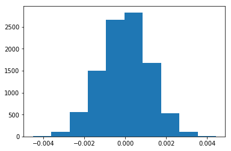

```python
p_diffs=np.array(p_diffs)
plt.hist(p_diffs)
plt.show()
```

Proportion of the **p_diffs** are greater than the actual difference observed in **ab_data.csv**

```
0.9053
```

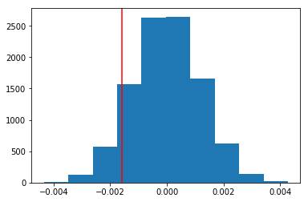

```python
convert_new = df2.query('converted == 1 and landing_page == "new_page"')['user_id'].nunique()
convert_old = df2.query('converted == 1 and landing_page == "old_page"')['user_id'].nunique()
actual_cvt_new = float(convert_new)/ float(n_new)
actual_cvt_old = float(convert_old)/ float(n_old)
obs_diff = actual_cvt_new - actual_cvt_old
null_vals = np.random.normal(0, p_diffs.std(), p_diffs.size)
plt.hist(null_vals)
#Plot vertical line for observed statistic
plt.axvline(x=obs_diff,color ='red')
(null_vals > obs_diff).mean()
```

> Explanation

#### P-Value: The probability of observing our statistic or a more extreme statistic from the null hypothesis.

We could also use a built-in to achieve similar results. Though using the built-in might be easier to code, the above portions are a walkthrough of the ideas that are critical to correctly thinking about statistical significance.Calculate the number of conversions for each page, as well as the number of individuals who received each page. Let `n_old` and `n_new` refer the number of rows associated with the old page and new pages, respectively.

```python
import statsmodels.api as sm

convert_old = df2.query('group == "control"')['converted'].mean()
convert_new = df2.query('group == "treatment"')['converted'].mean()
n_old = df2.query('landing_page == "old_page"').shape[0]
n_new = df2.query('landing_page == "new_page"').shape[0]
```

```python
n_old
```

```
145274
```

Now using `stats.proportions_ztest` to compute our test statistic and p-value.

```python
z_score, p_val=sm.stats.proportions_ztest([convert_old, convert_new], [n_old, n_new])
z_score, p_val
```

```
(0.0032875796753531767, 0.9973768956597913)
```

What do the z-score and p-value computed above mean for the conversion rates of the old and new pages? Do they agree with the findings beforehand.

It indicates that the difference is insignificant.

Hence null hypothesis cannot be rejected which agree with our findings beforehand.

### Part III - A regression approach

`1.`The result we achieved in the A/B test in Part II above can also be achieved by performing regression.

Type of regression we should be performing in this case.

Logistic regression because here we are dealing with categorical variables.

```python
df2['intercept']=1
df2=df2.join(pd.get_dummies(df['landing_page']))
df2['ab_page']=pd.get_dummies(df2['group'])['treatment']
df2.head()
```

|  | user_id | timestamp | group | landing_page | converted | intercept | new_page | old_page | ab_page |
| --- | --- | --- | --- | --- | --- | --- | --- | --- | --- |
| 0 | 851104 | 2017-01-21 22:11:48.556739 | control | old_page | 0 | 1 | 0.0 | 1.0 | 0 |
| 1 | 804228 | 2017-01-12 08:01:45.159739 | control | old_page | 0 | 1 | 0.0 | 1.0 | 0 |
| 2 | 661590 | 2017-01-11 16:55:06.154213 | treatment | new_page | 0 | 1 | 1.0 | 0.0 | 1 |
| 3 | 853541 | 2017-01-08 18:28:03.143765 | treatment | new_page | 0 | 1 | 1.0 | 0.0 | 1 |
| 4 | 864975 | 2017-01-21 01:52:26.210827 | control | old_page | 1 | 1 | 0.0 | 1.0 | 0 |

Using **statsmodels** to instantiate regression model on the two columns you created in above, then fitting the model using the two columns you created beforehand to predict whether or not an individual converts.

```python
results=sm.Logit(df2['converted'],df2[['intercept','ab_page']]).fit()
```

```
Optimization terminated successfully.
         Current function value: 0.366118
         Iterations 6
```

Summary of the model below

```python
results.summary()
```

Logit Regression Results

| Dep. Variable: | converted | No. Observations: | 290585 |
| --- | --- | --- | --- |
| Model: | Logit | Df Residuals: | 290583 |
| Method: | MLE | Df Model: | 1 |
| Date: | Fri, 22 Feb 2019 | Pseudo R-squ.: | 8.085e-06 |
| Time: | 12:06:59 | Log-Likelihood: | -1.0639e+05 |
| converged: | True | LL-Null: | -1.0639e+05 |
|  |  | LLR p-value: | 0.1897 |

|  | coef | std err | z | P>\|z\| | [0.025 | 0.975] |
| --- | --- | --- | --- | --- | --- | --- |
| intercept | -1.9888 | 0.008 | -246.669 | 0.000 | -2.005 | -1.973 |
| ab_page | -0.0150 | 0.011 | -1.312 | 0.190 | -0.037 | 0.007 |

Now, considering other things that might influence whether or not an individual converts.

We can consider adding new factors such timestamp to decide whether it plays an important role in predicting the results better.

Time stamp can be fuether divided into categories such as morning, Afternoon, Evening etc.

A disadvantage of adding new factors is that it will make the results complex further if the new factors are dependable with existing explanatory variables then we need to add more complex and higher order terms to help predict better results.

Now along with testing if the conversion rate changes for different pages, also adding an effect based on which country a user lives in.

```python
c=pd.read_csv('countries.csv')
c.head()
```

|  | user_id | country |
| --- | --- | --- |
| 0 | 834778 | UK |
| 1 | 928468 | US |
| 2 | 822059 | UK |
| 3 | 711597 | UK |
| 4 | 710616 | UK |

```python
df3=df2.merge(c,on='user_id',how='left')
c.country.unique()
```

```
array(['UK', 'US', 'CA'], dtype=object)
```

```python
df3[['CA','US','UK']]=pd.get_dummies(df3['country'])
```

```python
df3=df3.drop(df3['CA'])
df3.head()
```

|  | user_id | timestamp | group | landing_page | converted | intercept | new_page | old_page | ab_page | country | CA | US | UK |
| --- | --- | --- | --- | --- | --- | --- | --- | --- | --- | --- | --- | --- | --- |
| 2 | 661590 | 2017-01-11 16:55:06.154213 | treatment | new_page | 0 | 1 | 1.0 | 0.0 | 1 | US | 0 | 0 | 1 |
| 3 | 853541 | 2017-01-08 18:28:03.143765 | treatment | new_page | 0 | 1 | 1.0 | 0.0 | 1 | US | 0 | 0 | 1 |
| 4 | 864975 | 2017-01-21 01:52:26.210827 | control | old_page | 1 | 1 | 0.0 | 1.0 | 0 | US | 0 | 0 | 1 |
| 5 | 936923 | 2017-01-10 15:20:49.083499 | control | old_page | 0 | 1 | 0.0 | 1.0 | 0 | US | 0 | 0 | 1 |
| 6 | 679687 | 2017-01-19 03:26:46.940749 | treatment | new_page | 1 | 1 | 1.0 | 0.0 | 1 | CA | 1 | 0 | 0 |

```python
df3['intercept']=1
```

```python
df3['new_page'].value_counts()
```

```
1.0    143374
0.0    143368
Name: new_page, dtype: int64
```

```python
log_mod = sm.Logit(df3['converted'], df3[['intercept','ab_page','UK', 'US']])
results = log_mod.fit()
results.summary()
```

```
Optimization terminated successfully.
         Current function value: 0.366114
         Iterations 6
```

Logit Regression Results

| Dep. Variable: | converted | No. Observations: | 290583 |
| --- | --- | --- | --- |
| Model: | Logit | Df Residuals: | 290579 |
| Method: | MLE | Df Model: | 3 |
| Date: | Fri, 22 Feb 2019 | Pseudo R-squ.: | 2.326e-05 |
| Time: | 12:24:39 | Log-Likelihood: | -1.0639e+05 |
| converged: | True | LL-Null: | -1.0639e+05 |
|  |  | LLR p-value: | 0.1756 |

|  | coef | std err | z | P>\|z\| | [0.025 | 0.975] |
| --- | --- | --- | --- | --- | --- | --- |
| intercept | -2.0300 | 0.027 | -76.248 | 0.000 | -2.082 | -1.978 |
| ab_page | -0.0150 | 0.011 | -1.309 | 0.191 | -0.037 | 0.007 |
| UK | 0.0408 | 0.027 | 1.516 | 0.129 | -0.012 | 0.093 |
| US | 0.0506 | 0.028 | 1.784 | 0.075 | -0.005 | 0.106 |

From the result above it is clear that the use of columns is not significant in predicting the conversion rate as depicted by the p-values.

```python
1/np.exp(-0.015),np.exp(0.0408),np.exp(0.0506)
```

```
(1.015113064615719, 1.0416437559600236, 1.0519020483004984)
```

##### Interpreting Result:

##### For every unit for new_page decrease, convert will be 1.5% more likely to happen, holding all other varible constant.

Though we have now looked at the individual factors of country and page on conversion, we would now like to look at an interaction between page and country to see if there significant effects on conversion.

```python
df3['UK_new_page'] = df3['ab_page']* df3['UK']
df3['US_new_page'] = df3['ab_page']* df3['US']
logit4 = sm.Logit(df3['converted'], df3[['intercept','ab_page','UK_new_page','US_new_page','UK','US']])
result4 = logit4.fit()
result4.summary()
```

```
Optimization terminated successfully.
         Current function value: 0.366110
         Iterations 6
```

Logit Regression Results

| Dep. Variable: | converted | No. Observations: | 290583 |
| --- | --- | --- | --- |
| Model: | Logit | Df Residuals: | 290577 |
| Method: | MLE | Df Model: | 5 |
| Date: | Fri, 22 Feb 2019 | Pseudo R-squ.: | 3.485e-05 |
| Time: | 12:30:34 | Log-Likelihood: | -1.0639e+05 |
| converged: | True | LL-Null: | -1.0639e+05 |
|  |  | LLR p-value: | 0.1915 |

|  | coef | std err | z | P>\|z\| | [0.025 | 0.975] |
| --- | --- | --- | --- | --- | --- | --- |
| intercept | -2.0040 | 0.036 | -55.008 | 0.000 | -2.075 | -1.933 |
| ab_page | -0.0674 | 0.052 | -1.297 | 0.195 | -0.169 | 0.034 |
| UK_new_page | 0.0469 | 0.054 | 0.871 | 0.384 | -0.059 | 0.152 |
| US_new_page | 0.0783 | 0.057 | 1.378 | 0.168 | -0.033 | 0.190 |
| UK | 0.0176 | 0.038 | 0.466 | 0.641 | -0.056 | 0.091 |
| US | 0.0118 | 0.040 | 0.296 | 0.767 | -0.066 | 0.090 |

```python
np.exp(result4.params)
```

```
intercept      0.134794
ab_page        0.934776
UK_new_page    1.047966
US_new_page    1.081428
UK             1.017705
US             1.011854
dtype: float64
```

# Interpreting the result

#### Convert is 1.08 times more likely to happen for US and new page users than CA and new page users, holding all other varible constant.

#### Convert is 1.04 times more likely to happen for UK and new page users than CA and new page users, holding all other varible constant.

#### Convert is 1.18 % more likely to happen for the users in US than CA, holding all other varible constant.

#### Convert is 1.76 % more likely to happen for the users in UK than CA, holding all other varible constant.